# Figure 1c: Identifying CBP peaks with differential H3K27ac using DESeq2

**Project:** Enhancer identification

**Author:** Jeff Johnston

**Generated:** Wed Aug 24 2016, 08:09 PM

## Overview

Outline:

- Call peaks in Nej (wild-type) sample
- Divide into groups: near TSS, inside gene, intergenic
- Measure H3K27Ac signal in 1kb window around summit for Toll10b and gd7
- Identify peaks with differential H3K27Ac (DESeq2)
- Find enriched motifs using multiple window sizes around summits

## Peak calling

Peakzilla was run for the Nej IP sample against an Oregon-R WCE, yielding the following number of peaks:

| Sample | Peaks |
| --- | --- |
| Nej wild-type | 16,502 |

We will first filter these peaks to include only those that are at least 2-fold enriched over background (measured in a 201bp window at the summit):

| Sample | Peaks |
| --- | --- |
| Nej | 15,477 |

## Classify peaks by proximity to nearest gene

Each peak will be assigned to one of the following categories:

- TSS (within 1kb of a TSS)
- Inside gene
- Intergenic

| classification | Count |
| --- | --- |
| Inside_Gene | 4,342 |
| Intergenic | 2,806 |
| TSS | 8,329 |

## DESeq

Using the H3K27Ac read counts for two replicates each of Toll10b and gd7 samples, we call differentially-bound peaks using DESeq2. This results in the following numbers of peaks (adjusted p-value < 0.01):

Differential regions summary

| status | count |
| --- | --- |
| Higher in gd7 | 572 |
| Higher in Toll10b | 594 |
| No change | 14,311 |

Differential regions by classification

| classification | No_Change | Up_gd7 | Up_Toll10b |
| --- | --- | --- | --- |
| Inside_Gene | 3,789 | 267 | 286 |
| Intergenic | 2,563 | 113 | 130 |
| TSS | 7,959 | 192 | 178 |

Below is a plot of the H3K27Ac signal at each peak for the two tissues, highlighting those called significantly different by DESeq:

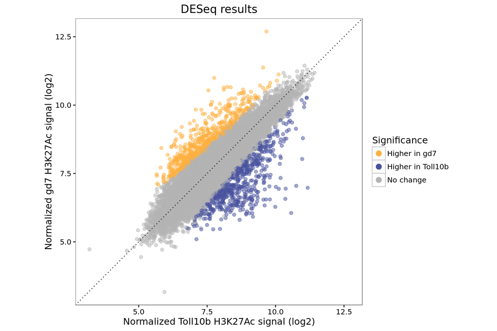

Of the 59 known enhancers, 34 overlap a Nej-bound differential H3K27Ac region.

Including only non-TSS regions, we detect differential H3K27Ac at 22 known enhancers.